# R Notebook

# Logistic Regression

binary dependent variable: (0 or 1)

- spam emails or not
- married or not
- clicked or not
- cat or dog
- organic or conventional
- registered user or not
- accepted or not mortgages

```r
library(tidyverse)
library(janitor)
```

```r
mortgage_data <- read_csv("data/mortgage_applications.csv") %>%
  clean_names()
head(mortgage_data)
```

| tu_score | employed | age | accepted |
| --- | --- | --- | --- |
| 433 | TRUE | 28 | TRUE |
| 93 | TRUE | 52 | FALSE |
| 368 | FALSE | 63 | FALSE |
| 665 | TRUE | 42 | TRUE |
| 687 | TRUE | 38 | TRUE |
| 594 | TRUE | 27 | FALSE |

[output not shown]

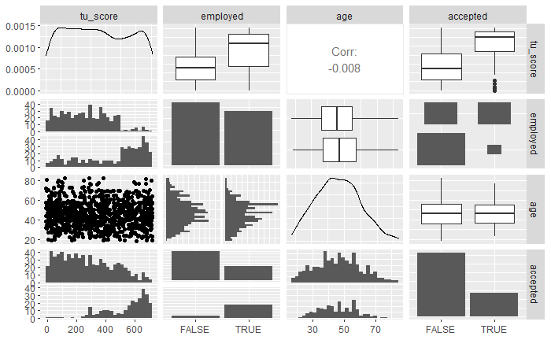

```r
library(GGally)
ggpairs(mortgage_data)
```

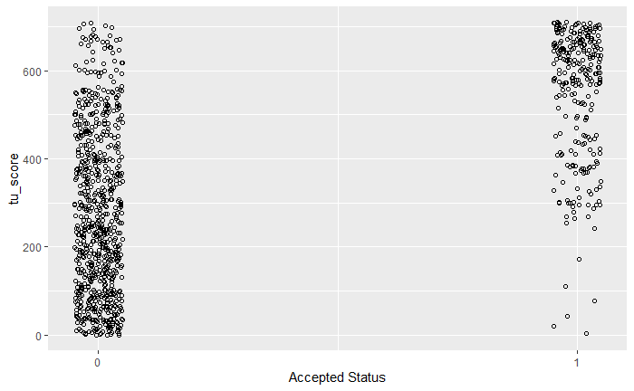

```r
# Let's reduce the symbol size and 'jitter' the y-values so we can see more of the data without overlap of symbols
# geom_jitter() adds adds a small amount of random variation (vertically and/ore horizontally depending on the arguments) to the location of each point

score_plot <- ggplot(mortgage_data) +
  geom_jitter(aes(y = tu_score, x = as.integer(accepted)), shape = 1,
              position = position_jitter(width = 0.05)) +
  xlab("Accepted Status") + scale_x_continuous(breaks=seq(0, 1,1))

score_plot
```

# Logistic Function

Logistic regession is estimating the LOG ODDS OF AN EVENT, RATHER THAN THE PROBABILTITY.

ask - 2 mins If we roll a fair die, what are the odds of getting a 6?

Odds(success) = 1/6 / 5/6 = 0.2

```r
logit <- function(x){
  return(log(x/(1-x)))
}

logit_data <- tibble(p = seq(0.001, 0.999, 0.001)) %>%
  mutate(logit_p = logit(p))

head(logit_data)
```

| p | logit_p |
| --- | --- |
| 0.001 | -6.906755 |
| 0.002 | -6.212606 |
| 0.003 | -5.806138 |
| 0.004 | -5.517453 |
| 0.005 | -5.293305 |
| 0.006 | -5.109978 |

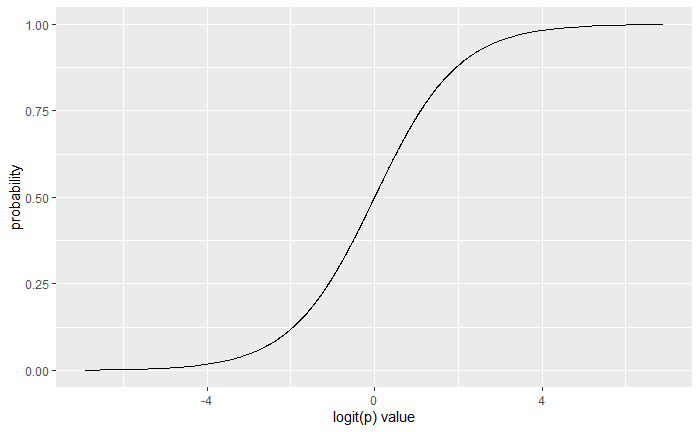

```r
ggplot(logit_data, aes(y = p, x = logit_p)) +
  geom_line() +
  ylab("probability") + xlab("logit(p) value")
```

**Build a model that predicts the probaility of a loan being accepted or not, given a tu_score**

1. Build the logistis model

```r
mortgage_data_log_model <- glm(accepted ~ tu_score, data = mortgage_data,
                               family = binomial(link = "logit"))

mortgage_data_log_model
```

```
Call:  glm(formula = accepted ~ tu_score, family = binomial(link = "logit"),
    data = mortgage_data)

Coefficients:
(Intercept)     tu_score
  -4.575035     0.008475

Degrees of Freedom: 999 Total (i.e. Null);  998 Residual
Null Deviance:      1170
Residual Deviance: 792.1    AIC: 796.1
```

2. Add these predictions into your dataset

```r
library(modelr)

predict_log <- tibble(tu_score = seq(0, 710, 1)) %>%
  add_predictions(mortgage_data_log_model, type = "response")
```

3. Check model fits the data?

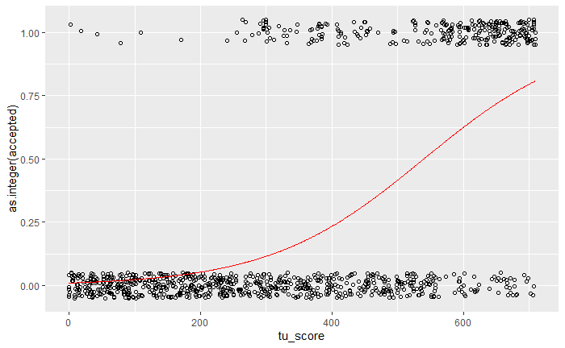

```r
ggplot(mortgage_data) +
  geom_jitter(aes(x = tu_score, y = as.integer(accepted)), shape = 1,
              position = position_jitter(h = 0.05)) +
  geom_line(data = predict_log, aes(x = tu_score, y = pred), col = 'red')
```

Task - 5 mins Use and amend the code above to predict the probability of getting a mortgage application accepted with a tu_score of 594.

```r
predict_log_task <- tibble(tu_score = 594) %>%
  add_predictions(mortgage_data_log_model, type = "response")

predict_log_task
```

| tu_score | pred |
| --- | --- |
| 594 | 0.6127971 |

60% of people will get a mortgage application accepted

1/1 + e(b0 = b1 * x)

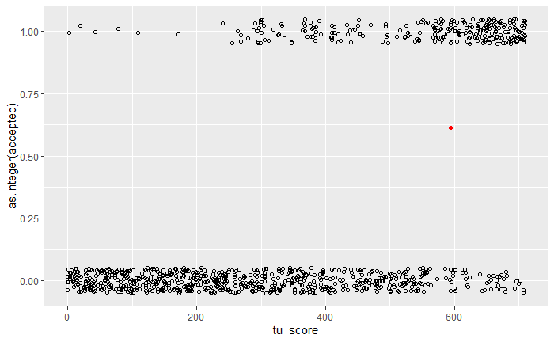

```r
ggplot(mortgage_data) +
  geom_jitter(aes(x = tu_score, y = as.integer(accepted)), shape = 1,
              position = position_jitter(h = 0.05)) +
  geom_point(data = predict_log_task, aes(x = tu_score, y = pred), col = 'red')
```

4. Interpreting the B1 for a continuous predictor (tu_score)

If the independent variable increases by one unit, then the estimate of the log odds of suscces changes (increases or decreases) by B1 units.

Calculate the odds of having an accepted application at tu_score = 594:

```r
odds_at_594 <- tibble(tu_score = 594) %>%
  add_predictions(mortgage_data_log_model, type = "response") %>%
  mutate(odds = pred / (1-pred))

odds_at_594
```

| tu_score | pred | odds |
| --- | --- | --- |
| 594 | 0.6127971 | 1.582625 |

How do these odds change if we increase the tu_score by 50 points?

```r
library(broom)
```

```r
mortgage_data_log_model
```

```
Call:  glm(formula = accepted ~ tu_score, family = binomial(link = "logit"),
    data = mortgage_data)

Coefficients:
(Intercept)     tu_score
  -4.575035     0.008475

Degrees of Freedom: 999 Total (i.e. Null);  998 Residual
Null Deviance:      1170
Residual Deviance: 792.1    AIC: 796.1
```

Take the above details and make a table to read it easier below

```r
b_tu_score <- tidy(mortgage_data_log_model) %>%
  filter(term == "tu_score") %>%
  select(estimate)

b_tu_score
```

| estimate |
| --- |
| 0.00847495 |

```r
odds_factor <- exp(b_tu_score * 50)

odds_factor
```

| estimate |
| --- |
| 1.527676 |

Calculate the new odds of getting a loan accepted or not, based on a 50 point increase in tu_score

```r
odds_at_594 <- odds_at_594 %>%
  select(odds)

odds_at_594
```

| odds |
| --- |
| 1.582625 |

```r
new_odds <- odds_factor * odds_at_594

new_odds
```

| estimate |
| --- |
| 2.417739 |

```r
odds_at_644 <- tibble(tu_score = 644) %>%
  add_predictions(mortgage_data_log_model, type = "response") %>%
  mutate(odds = pred / (1-pred))

odds_at_644
```

| tu_score | pred | odds |
| --- | --- | --- |
| 644 | 0.7074089 | 2.417739 |

Task - 5 mins How do the odds of acceptance change if we decrease tu_score by 50 points from 594 to 544? Calculate the new odds using R.

[Hint - the change in x here is −50]

```r
odds_at_544 <- tibble(tu_score = 544) %>%
  add_predictions(mortgage_data_log_model, type = "response") %>%
  mutate(odds = pred / (1-pred))

odds_at_544
```

| tu_score | pred | odds |
| --- | --- | --- |
| 544 | 0.5088335 | 1.035969 |

# Multiple predictors

Make a new model with multiple predictors

```r
mortgage_multi_log_model <- glm(accepted ~ tu_score + employed + age,
                                data = mortgage_data,
                                family = binomial(link = 'logit'))

mortgage_multi_log_model
```

```
Call:  glm(formula = accepted ~ tu_score + employed + age, family = binomial(link = "logit"),
    data = mortgage_data)

Coefficients:
 (Intercept)      tu_score  employedTRUE           age
    -4.62854       0.00673       1.48034      -0.00126

Degrees of Freedom: 999 Total (i.e. Null);  996 Residual
Null Deviance:      1170
Residual Deviance: 740  AIC: 748
```

[output not shown]

tu_score and employedTRUE are significant

Final model: accepted ~ tu_score + employed

```r
b_employedTRUE <- tidy(mortgage_multi_log_model) %>%
  filter(term == "employedTRUE") %>%
  select(estimate)

exp(b_employedTRUE)
```

| estimate |
| --- |
| 4.394444 |

On average, a customer’s odds of being axxepted for a mortgage are 4.39 times higher if they are employed.

# Evaluating the Perfirmance of a Model

```r
mortgage_3pred_model <- glm(accepted ~ tu_score + employed + age,
                            data = mortgage_data,
                            family = binomial(link = 'logit'))

mortgage_data_with_3pred <- mortgage_data %>%
  add_predictions(mortgage_3pred_model, type = "response")
head(mortgage_data_with_3pred)
```

| tu_score | employed | age | accepted | pred |
| --- | --- | --- | --- | --- |
| 433 | TRUE | 28 | TRUE | 0.43306982 |
| 93 | TRUE | 52 | FALSE | 0.06992660 |
| 368 | FALSE | 63 | FALSE | 0.09698035 |
| 665 | TRUE | 42 | TRUE | 0.78149676 |
| 687 | TRUE | 38 | TRUE | 0.80651348 |
| 594 | TRUE | 27 | FALSE | 0.69327429 |

**Threshold probability**: cut off for whether a value gets classed as true or false, that depends on a prob level.

Set the threshold to 0.6

```r
threshold <-  0.6

mortgage_data_with_3pred <- mortgage_data_with_3pred %>%
  mutate(pred_thresh_0.6 = pred > threshold)

mortgage_data_with_3pred
```

| tu_score | employed | age | accepted | pred | pred_thresh_0.6 |
| --- | --- | --- | --- | --- | --- |
| 433 | TRUE | 28 | TRUE | 0.433069819 | FALSE |
| 93 | TRUE | 52 | FALSE | 0.069926601 | FALSE |
| 368 | FALSE | 63 | FALSE | 0.096980347 | FALSE |
| 665 | TRUE | 42 | TRUE | 0.781496763 | TRUE |
| 687 | TRUE | 38 | TRUE | 0.806513482 | TRUE |
| 594 | TRUE | 27 | FALSE | 0.693274287 | TRUE |
| 83 | FALSE | 24 | FALSE | 0.016299620 | FALSE |
| 172 | TRUE | 19 | FALSE | 0.117682879 | FALSE |
| 27 | FALSE | 45 | FALSE | 0.010948692 | FALSE |
| 232 | FALSE | 34 | FALSE | 0.042696972 | FALSE |

[output cut: 990 more lines]

Count how many times our classifier?model is correct - confusion matrix

```r
conf_table <- mortgage_data_with_3pred %>%
  tabyl(accepted, pred_thresh_0.6)

conf_table
```

```
 accepted FALSE TRUE
    FALSE   679   49
     TRUE    93  179
```

The table is pretty self-explanatory:

```
The ‘correct’ predictions, i.e. true negatives and true positives are on the top left to bottom right diagonal.
The ‘incorrect’ predictions, i.e. false negatives and false positives are on the bottom left to top right diagonal. A perfect classifier would have zeroes on this diagonal.
```

‘True’, ‘false’, ‘negative’ and ‘positive’ can be confusing terms at first. It might help to think that ‘negative’ and ‘positive’ are the outcomes predicted by the logistic regression and ‘true’ and ‘false’ relate to whether the prediction was correct with reference to the sample data.

```r
mortgage_data_with_3pred %>%
  filter(tu_score == 594)
```

| tu_score | employed | age | accepted | pred | pred_thresh_0.6 |
| --- | --- | --- | --- | --- | --- |
| 594 | TRUE | 27 | FALSE | 0.6932743 | TRUE |
| 594 | TRUE | 47 | FALSE | 0.6878897 | TRUE |
| 594 | TRUE | 33 | TRUE | 0.6916643 | TRUE |
| 594 | TRUE | 36 | TRUE | 0.6908576 | TRUE |
| 594 | TRUE | 45 | TRUE | 0.6884305 | TRUE |

# Accuracy Score

What is the accuracy of a classifier

$$\textrm{accuracy} = \frac{NTP + NTN}{N}$$

So, in our case, the classifier is $\frac{679+179}{1000}=0.858$ or $85.8\%$ accurate! This sounds great, but it isn’t enough. Accuracy has a **subtle weakness** that means we need to consider additional measures of performance for our classifier.

# Rates

Performance measures of the claaifier/model.

**true positive rate**
$$TPR = \frac{NTP}{NTP + NFN}$$

TPR: The number of positive cases that are correctly identified/classified. **Sensitivity** of a classifier.

**true negative rate**
$$TNR = \frac{NTN}{NTN + NFP}$$

**false positive rate**
$$FPR = \frac{NFP}{NFP + NTN}$$

FPR: False alarm rate - nagative cases that are incorrectly identified as a positive. **Type I Error**

**false negative rate**
$$FNR = \frac{NFN}{NFN + NTP}$$

FNR: incorrectly identifies a case as negative when it’s positive :( **Type II Error**

```r
NTP <- 179
NTN <- 679
NFP <- 49
NFN <- 93

TPR <- NTP / (NTP + NFN)
TNR <- NTN / (NTN + NFP)
FPR <- NFP / (NFP + NTN)
FNR <- NFN / (NFN + NTP)
```

```r
TPR
```

```
[1] 0.6580882
```

```r
TNR
```

```
[1] 0.9326923
```

```r
FPR
```

```
[1] 0.06730769
```

```r
FNR
```

```
[1] 0.3419118
```

# ROC curves, AUC values, Gini Coefficients and cross validation

```r
summary(mortgage_3pred_model)
```

```
Call:
glm(formula = accepted ~ tu_score + employed + age, family = binomial(link = "logit"),
    data = mortgage_data)

Deviance Residuals:
    Min       1Q   Median       3Q      Max
-1.8827  -0.5069  -0.2852   0.6390   2.9650

Coefficients:
               Estimate Std. Error z value Pr(>|z|)
(Intercept)  -4.6285393  0.4303344 -10.756  < 2e-16 ***
tu_score      0.0067301  0.0005692  11.823  < 2e-16 ***
employedTRUE  1.4803410  0.2114794   7.000 2.56e-12 ***
age          -0.0012600  0.0070634  -0.178    0.858
---
Signif. codes:  0 ‘***’ 0.001 ‘**’ 0.01 ‘*’ 0.05 ‘.’ 0.1 ‘ ’ 1

(Dispersion parameter for binomial family taken to be 1)

    Null deviance: 1170.48  on 999  degrees of freedom
Residual deviance:  739.95  on 996  degrees of freedom
AIC: 747.95

Number of Fisher Scoring iterations: 5
```

# ROC curves

```r
library(pROC)
```

```r
roc_obj_3pred <- mortgage_data_with_3pred %>%
  roc(response = accepted, predictor = pred)
```

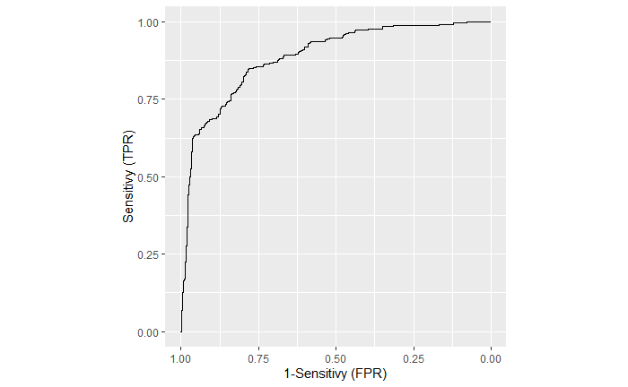

```r
ggroc(data = roc_obj_3pred, laegacy.axes =TRUE) +
  coord_fixed() +
  ylab("Sensitivy (TPR)") +
  xlab("1-Sensitivy (FPR)")
```

```r
classifier_data <- tibble(
  threshold = roc_obj_3pred$thresholds,
  sensitivity = roc_obj_3pred$sensitivities,
  specificity = roc_obj_3pred$specificities
)

head(classifier_data)
```

| threshold | sensitivity | specificity |
| --- | --- | --- |
| -Inf | 1 | 0.000000000 |
| 0.008881843 | 1 | 0.001373626 |
| 0.009012745 | 1 | 0.002747253 |
| 0.009131110 | 1 | 0.004120879 |
| 0.009273563 | 1 | 0.005494505 |
| 0.009395463 | 1 | 0.006868132 |

Task - 10 mins OK, let’s fit another classifier and add its curve to the ROC plot from earlier! Fit a single predictor logistic regression model to the `mortgage_data.` We recommend `tu_score` as the predictor. Save the model as `mortgage_1pred_model` Add the predicted probabilities from this model to `mortgage_data`, and save the resulting data as `mortgage_data_with_1pred` Use this data to generate an an object from `roc()`, save the object as `roc_obj_1pred` Pass your old `roc_obj_3pred` and new `roc_obj_1pred` into `ggroc()` [Hint check the ggroc() docs to see how to pass in multiple `roc` objects]. Given these ROC curves, which classifier is better? If you have time, try another single predictor, i.e. `age` or `employed`

```r
mortgage_1pred_model <- glm(accepted ~ tu_score,
                            data = mortgage_data,
                            family = binomial(link = 'logit'))

mortgage_data_with_1pred <- mortgage_data %>%
  add_predictions(mortgage_1pred_model, type = "response")
head(mortgage_data_with_1pred)
```

| tu_score | employed | age | accepted | pred |
| --- | --- | --- | --- | --- |
| 433 | TRUE | 28 | TRUE | 0.28794579 |
| 93 | TRUE | 52 | FALSE | 0.02216417 |
| 368 | FALSE | 63 | FALSE | 0.18904100 |
| 665 | TRUE | 42 | TRUE | 0.74284466 |
| 687 | TRUE | 38 | TRUE | 0.77682441 |
| 594 | TRUE | 27 | FALSE | 0.61279713 |

```r
threshold <-  0.6

mortgage_data_with_1pred <- mortgage_data_with_1pred %>%
  mutate(pred_thresh_0.6 = pred > threshold)

mortgage_data_with_1pred
```

| tu_score | employed | age | accepted | pred | pred_thresh_0.6 |
| --- | --- | --- | --- | --- | --- |
| 433 | TRUE | 28 | TRUE | 0.28794579 | FALSE |
| 93 | TRUE | 52 | FALSE | 0.02216417 | FALSE |
| 368 | FALSE | 63 | FALSE | 0.18904100 | FALSE |
| 665 | TRUE | 42 | TRUE | 0.74284466 | TRUE |
| 687 | TRUE | 38 | TRUE | 0.77682441 | TRUE |
| 594 | TRUE | 27 | FALSE | 0.61279713 | TRUE |
| 83 | FALSE | 24 | FALSE | 0.02039990 | FALSE |
| 172 | TRUE | 19 | FALSE | 0.04239748 | FALSE |
| 27 | FALSE | 45 | FALSE | 0.01279010 | FALSE |
| 232 | FALSE | 34 | FALSE | 0.06857122 | FALSE |

[output cut: 990 more lines]

```r
conf_table_1pred <- mortgage_data_with_1pred %>%
  tabyl(accepted, pred_thresh_0.6)

conf_table_1pred
```

```
 accepted FALSE TRUE
    FALSE   684   44
     TRUE   127  145
```

```r
NTP <- 145
NTN <- 684
NFP <- 44
NFN <- 127

TPR <- NTP / (NTP + NFN)
TNR <- NTN / (NTN + NFP)
FPR <- NFP / (NFP + NTN)
FNR <- NFN / (NFN + NTP)
```

```r
TPR
```

```
[1] 0.5330882
```

```r
TNR
```

```
[1] 0.9395604
```

```r
FPR
```

```
[1] 0.06043956
```

```r
FNR
```

```
[1] 0.4669118
```

```r
roc_obj_1pred <- mortgage_data_with_1pred %>%
  roc(response = accepted, predictor = pred)
```

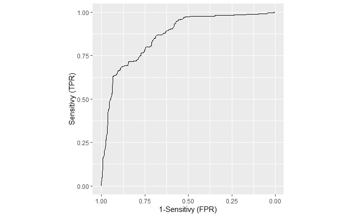

```r
ggroc(data = roc_obj_1pred, laegacy.axes =TRUE) +
  coord_fixed() +
  ylab("Sensitivy (TPR)") +
  xlab("1-Sensitivy (FPR)")
```

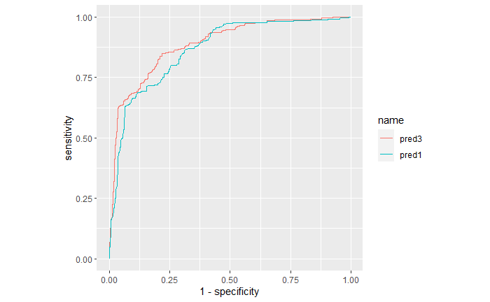

```r
roc_curve <- ggroc(data = list(pred3 = roc_obj_3pred, pred1 = roc_obj_1pred), legacy.axes = TRUE) +
  coord_fixed()

roc_curve
```

ROC - gives us a convienent way to compare performance of classifiers visually

AUC value - gives us a singular number to measure effectiveness of a classifier

AUC : Area under the Curve

```r
auc(roc_obj_3pred)
```

```
Area under the curve: 0.8881
```

```r
auc(roc_obj_1pred)
```

```
Area under the curve: 0.8666
```

Gini Coefficient: normalises AUC so that a total random classifier has 0 and a perfect classifier has 1 : not %

GINI = 2 * AUC -1

0 : 1

```r
gini1 <- 2 * 0.866 - 1
gini1
```

```
[1] 0.732
```

```r
gini3 <- 2 * 0.881 - 1
gini3
```

[output not shown]

# Cross Validation

```r
library(caret)
```

[output not shown]

[output cut: 990 more lines]

```r
train_control <- trainControl(method = "repeatedcv",
                              number = 5, # cuts data into 5 folds to test
                              repeats = 100,
                              savePredictions = TRUE,
                              classProbs = TRUE,
                              summaryFunction = twoClassSummary)
```

```r
model <- train(accepted ~ tu_score + employed + age,
               data = mortgage_data,
               trControl = train_control,
               method = "glm",
               family = binomial(link = "logit"))
```

```r
summary(model)
```

```
Call:
NULL

Deviance Residuals:
    Min       1Q   Median       3Q      Max
-1.8827  -0.5069  -0.2852   0.6390   2.9650

Coefficients:
              Estimate Std. Error z value Pr(>|z|)
(Intercept) -4.6285393  0.4303344 -10.756  < 2e-16 ***
tu_score     0.0067301  0.0005692  11.823  < 2e-16 ***
employedt    1.4803410  0.2114794   7.000 2.56e-12 ***
age         -0.0012600  0.0070634  -0.178    0.858
---
Signif. codes:  0 ‘***’ 0.001 ‘**’ 0.01 ‘*’ 0.05 ‘.’ 0.1 ‘ ’ 1

(Dispersion parameter for binomial family taken to be 1)

    Null deviance: 1170.48  on 999  degrees of freedom
Residual deviance:  739.95  on 996  degrees of freedom
AIC: 747.95

Number of Fisher Scoring iterations: 5
```

```r
model$results
```

|  | parameter | ROC | Sens | Spec | ROCSD | SensSD | SpecSD |
| --- | --- | --- | --- | --- | --- | --- | --- |
| 1 | none | 0.8861369 | 0.8807425 | 0.69553 | 0.02402807 | 0.02477479 | 0.05429828 |

Ricardo found this:

[output not shown]